# Fakultät für Physik

## Physikalisches Praktikum P2 für Studierende der Physik

Versuch P2-16, 17, 18 (Stand: April 2023)

[Raum F1-29](http://www-ekp.physik.uni-karlsruhe.de/~simonis/praktikum/layoutobjekte/Lageplan_P1.png)

Name: Alhelo Vorname: Fadi E-Mail: uylex@student.kit.edu

\begin{equation*} \begin{split} &\\ &\\ \end{split} \end{equation*}

Name: Ji Vorname: Tony E-Mail: uvsvo@student.kit.edu

\begin{equation*} \begin{split} &\\ &\\ &\\ \end{split} \end{equation*}

Gruppennummer: Do-14

\begin{equation*} \begin{split} &\\ &\\ &\\ \end{split} \end{equation*}

Betreuer: __________________

\begin{equation*} \begin{split} &\\ &\\ &\\ \end{split} \end{equation*}

Versuch durchgeführt am: __________________

**Beanstandungen:**

\begin{equation*} \begin{split} &\\ &\\ &\\ &\\ &\\ &\\ &\\ &\\ &\\ &\\ \end{split} %\text{\vspace{10cm}} \end{equation*}

Testiert am: __________________ Vermerk: __________________

# Laser-Optik, Teil A

## Motivation

Mit diesem Versuch lernen Sie die grundlegenden Konzepte von [Lasern](https://de.wikipedia.org/wiki/Laser) und ihrer Anwendung in der modernen Physik kennen. Darüber hinaus können Sie Ihr Verständnis der Eigenschaften von Licht und elektromagnetischen Wellen vertiefen.

Das Laser (*light amplification by stimulated emission of radiation*)-Prinzip beruht auf der 1916 von Albert Einstein erstmals beschriebenen stimulierten Emission elektromagnetischer Wellen. Der erste funktionsfähige Maser –noch im Mikrowellenbereich– wurde 1954 von [Charles Townes](https://de.wikipedia.org/wiki/Charles_H._Townes) realisiert. Die Übertragung des Maser-Prinzips zu den kürzeren Wellenlängen des sichtbaren Lichts gelang [Theodore Maiman](https://de.wikipedia.org/wiki/Theodore_Maiman) 1960 mit dem ersten Rubinlaser. Seitdem wurden die Eigenschaften und Leistungsfähigkeit von Lasern kontinuierlich erweitert und verbessert. Laser sind eine brillante Quelle für [hoch-kohärentes Licht](https://de.wikipedia.org/wiki/Koh%C3%A4renzl%C3%A4nge). Sie sind damit Wegbereiter für interferometrische Längenmessungen oder die Untersuchung quantenmechanisch verschränkter Zustände. Sie finden Anwendung beim Nachweis von [Gravitationswellen](https://de.wikipedia.org/wiki/Gravitationswelle) sowie bei der Erzeugung von Qbits im [Quantencomputing](https://de.wikipedia.org/wiki/Quantencomputer). Von der Kommunikation und Datenspeicherung bis hin zur Materialbearbeitung und Medizin sind Laser zu wichtigen Werkzeugen in Wissenschaft und Technik geworden.

## Lernziele

Wir listen im Folgenden die wichtigsten **Lernziele** auf, die wir Ihnen mit dem Versuch **Laser-Optik, Teil A** vermitteln möchten:

- Sie machen sich mit dem Funktionsprinzip und den Eigenschaften eines Lasers vertraut.
- Sie üben sich darin optische Bauelemente entlang eines Laserstrahls auszurichten.
- Sie verwenden den Laser als ideale (kohärente) Lichtquelle für verschiedene Beugungs- und Interferenzmessungen.
- Sie erstellen eine holographische Abbildung.
- Sie erfahren, wie Laser in modernen Forschungsfeldern, so wie der Kommunikation, der medizinischen Diagnostik und der Materialbearbeitung eingesetzt werden.

## Versuchsaufbau

Auf einer optischen Bank können neben einem $\mathrm{He}$-$\mathrm{Ne}$-Laser mehrere optische Bauelemente montiert werden. Zur Verfügung stehen mehrere Spalte, Blenden und Gitter, wie in der folgenden Photographie abgebildet: ([Link](https://git.scc.kit.edu/etp-lehre/p2-for-students/-/raw/main/Laser-Optik_Teil_A/figures/LaserA.jpg))

[figure not shown]

Für die verschiedenen Versuchsteile stehen Ihnen die folgenden Geräte und Materialien zur Verfügung:

- Ein offener $\mathrm{He}$-$\mathrm{Ne}$-Laser, (Spindler & Hoyer Typ 500, zu Demonstrationszwecken). Der Laser hat eine Leistung von $P=2\,\mathrm{mW}$ bei einer Wellenlänge von $\lambda=632,8\,\mathrm{nm}$. Er verfügt über ein Entladungsrohr, (um eine horizontale Achse gekippte) Brewster-Fenster, zwei Resonatorspiegel (mit Reflexionsgraden $R=99,7\,\%$ und $R=98\,\%$), entsprechende Schutzkappen, ein Versorgungsgerät, Filterkappen und ein Justierkreuz. Der Bereich zwischen Spiegel und Brewster-Fenster ist für Experimente zugänglich. **Dieser Aufbau ist nur einfach vorhanden!**
- $\mathrm{He}$-$\mathrm{Ne}$-Laser, Polytec PL-610P, mit einer Leistung von $P=5\,\mathrm{mW}$ (in geschlossener Bauform mit integriertem Netzteil, für polarisiertes Licht, siehe Bild). Ein solcher Laser befindet sich an allen Plätzen.
- Ein Experimentiertisch (mit $3\,\mathrm{m}$-Zeißschiene), diverse Reiter und Verschiebereiter.
- Ein kleinflächiger Lichtdetektor mit Phototransistor, in einem Gehäuse mit Anschlussbuchsen für eine Betriebsgleichspannung zwischen $9-15\,\mathrm{V}$ und ein entsprechendes Messinstrument. Dieser Lichtdetektor besitzt, durch eine entsprechende Frontlinse, eine ausgeprägte Richtcharakteristik. Er ist sehr lichtempfindlich und leicht übersteuerbar. Er ist deshalb nur für geringe Lichtintensität vorgesehen.
- Ein Netzgerät ($2\times15\,\mathrm{V}$), für den Phototransistor. Sie können $1\times15\,\mathrm{V}$ sowohl an der roten als auch an der schwarzen Buchse abgreifen.
- Ein großflächiger Lichtdetektor mit $\mathrm{Si}$-Photoelement (Durchmesser der Photodiode $d=12\,\mathrm{mm}$). Betreiben Sie diesen Lichtdetektor nur im Elementbetrieb, d.h. schließen Sie ihn ohne Betriebsspannung direkt an ein Spannungs- oder Strommessgerät an.
- Vielfachmessinstrument (Metex 3800 mit digitaler LCD-Anzeige, alle benötigten Messbereiche verfügbar), mit gleichem Innenwiderstand für alle Gleichstrombereiche. Daher ist die Anzeige auch über die Bereichsgrenzen hinaus proportional zur Intensität im $\mathrm{Si}$-Photoelement; Achtung: Verwenden Sie für die Schalterstellung des $20\,\mathrm{A}$-Bereichs die spezielle $20\,\mathrm{A}$-Buchse, die allgemeine $\mathrm{A}$-Buchse ist nur für Messungen im $20\,\mu\mathrm{A}$-Bereich vorgesehen.
- Ein Strahlaufweitungssystem, bestehend aus einer Mikrobank auf einem Stift. Auf der Mikrobank befinden sich in entsprechenden Haltern spezielle, für die Laserlicht-Wellenlänge korrigierte Linsen mit Brennweiten von $f_{1}=10\,\mathrm{mm}$ und $f_{2}=150\,\mathrm{mm}$ im Abstand $f_{1}+f_{2}$, als [telezentrisches System](https://de.wikipedia.org/wiki/Telezentrisches_Objektiv).
- Ein Justieraufbau, bestehend aus einer Mikrobank auf einem Stift. Auf der Mikrobank befinden sich drei verschiebbare $25\,\mathrm{mm}$-Bauteil-Halter, von denen mindestens einer transversal justierbar ist.
- Diverse Halter für Linsen, Blenden, Hologramme und sonstiges.
- Ein Eisen-Schirm mit Haftmagneten, um Papier daran zu befestigen, ein Planspiegel auf einem Stift mit Kugelgelenk.
- Eine Mattscheibe (in einem Halter auf einem Stift), eine Glasplatte (in einem Halter, drehbar um die horizontale Achse, mit Winkelskala).
- Ein Polarisationsfilter (mit Durchmesser $d=10\,\mathrm{cm}$, auf einem Stift, drehbar, mit Winkelskala). **Diesen sollten Sie nicht im unaufgeweiten Strahl benutzen!**
- Ein Hologramm ($8,5\,\mathrm{cm}\times10\,\mathrm{cm}$), in einem Halter auf einem Stift.
- Im Dia-Format:
  - Strichgitter mit $570\,\mathrm{Strichen/mm}$,
  - Kreuzgitter mit $13,4\,\mathrm{Strichen/mm}\times15\,\mathrm{Strichen/mm}$,
  - Kreuzgitter mit $2,6\,\mathrm{Strichen/mm}\times3,8\,\mathrm{Strichen/mm}$;
  - Kreisblende mit Durchmessern $d=1;\,1.5;\,2\,\mathrm{mm}$.
- In $25\,\mathrm{mm}$-Fassungen:
  - Strichgitter mit $100\,\mathrm{Strichen/cm}$,
  - Kreuz- und Wabengitter (ohne Dimensionsangabe),
  - Beugungsordnungsblende mit 5 speziellen Öffnungen,
  - Beugungskante,
  - Lochblende, mit Durchmesser $d=1\,\mathrm{mm}$,
  - Scheibenblende, mit Durchmesser $d=1\,\mathrm{mm}$,
  - Beugungssteg mit Breite $b=0,3\,\mathrm{mm}$,
  - Verschiedene Spalten mit Breite $b=0,2\,\mathrm{mm}$, $0,3\,\mathrm{mm}$ und $0,4\,\mathrm{mm}$.
  - Doppelspalte mit den folgenden Spaltbreiten ($b$) und Abständen ($\ell$): $b=0,25\,\mathrm{mm}$, $\ell=0,5\,\mathrm{mm}$ und $b=0,25\,\mathrm{mm}$, $\ell=0,75\,\mathrm{mm}$,
  - Dreifachspalt mit Spaltbreite $b=0,25\,\mathrm{mm}$ und Abstand $\ell=0,5\,\mathrm{mm}$,
  - Vierfachspalt mit Spaltbreite $b=0,2\,\mathrm{mm}$ und Abstand $\ell=0,3\,\mathrm{mm}$,
  - Einstellspalt, Irisblende, Polarisationsfilter ohne Skala.
  - Linsen mit verschiedenen Brennweiten zwischen $10-150\,\mathrm{mm}$.
- Tischlampe, Taschenlampe, Maßband, Reinigungsutensilien.

## Wichtige Hinweise

- Bei diesem Versuch arbeiten Sie mit einem Laser, der entsprechend **gefährlich für Ihre Augen** sein kann. Gehen Sie daher **vorsichtig und verantwortungsbewusst** mit dem Laser um und halten Sie sich an die Anweisungen des/der Tutor:in.
- Achten Sie darauf, dass alle Personen im Raum bei der Durchführung des Versuchs eine **Schutzbrille** tragen.
- Vermeiden Sie direkten Blickkontakt mit dem Laserstrahl und richten Sie ihn niemals auf andere Personen. Bleiben Sie beim Experimentieren in der Regel stehen, mit den Augen also weit oberhalb der Strahlhöhe.
- Stellen Sie sicher, dass die Laserleistung und -frequenz auf die vorgesehenen Werte eingestellt sind und überprüfen Sie dies regelmäßig während des Experiments.
- Beachten Sie, dass der Laserstrahl bei falscher Handhabung Schäden an optischen Elementen verursachen kann. Verwenden Sie nur die bereitgestellten optischen Elemente und reinigen Sie sie nur mit geeigneten Materialien.
- Vor dem Einschalten des Lasers müssen alle Geräte sorgfältig aufgebaut und justiert werden. Führen Sie diese Schritte **erst nach Rücksprache mit dem/der Tutor:in** durch.

## Durchführung

### **Aufgabe 1: Bestimmung des [Brewsterwinkels](https://de.wikipedia.org/wiki/Brewster-Winkel)**

Bei Gaslasern wird das [Entladungsrohr](https://de.wikipedia.org/wiki/Gasentladungsr%C3%B6hre) meist mit "Brewster-Fenstern" abgeschlossen. Überlegen Sie sich den Sinn dafür und demonstrieren Sie die Notwendigkeit. Gehen Sie dabei wie folgt vor:

Montieren Sie einen drehbaren Plattenhalter mit planparalleler, sorgfältig geputzter Glasscheibe vor den Laser, verändern Sie den Einfallswinkel und beobachten Sie die Strahlintensität. Bestimmen Sie den Brewsterwinkel, und daraus den Brechungsindex $n$ des Glases. Sie können das Minimum der Reflexion ohne Intensitätsmessung an der Zimmerdecke beobachten. Für die Beobachtung des Maximums der Transmission können Sie z.B. das Si-Photoelement mit geeignetem Messinstrument benutzen. Ein solches Vorgehen ist aber ungenauer als die Beobachtung des Minimums. Diskutieren Sie warum dies so ist.

**Lösung:**

#### Definition des Brewserwinkel

Fallt ein Lichtstrahl auf eine Grenzfläche zwischen 2 Medien (von dem Medium mit Brechungs-index $n_1$ kommend, in das Medium mit $n_2$ wobei $n_2 > n_1$ gilt), so ist der Brewsterwinkel $\theta$ der Winkel, fur den der reflektierte Strahl vollständig linear polarisiert ist. Der gebrochene und reflektierte Strahl stehen hierbei senkrecht aufeinander. Dabei gilt dann: $$ \tan\left(\theta\right) = \frac{n_2}{n_1} $$ Um den Brewsterwinkel zu bestimmen gibt es zwei Verfahren:

- Methode der minimalen Reflexion
- Mehtode der maximalen Transmission

Für beide Verfahren wird zuerst eine drehbare Glasscheibe im Weg des Lasers montiert.

#### Methode der minimalen Reflexion

Fällt der Laserstrahl unter dem Brewsterwinkel auf die Glasplatte, wird ein Minimum bei der Reflexion beobachtet, da der Laserstrahl polarisiert ist. Es wird im Idealfall eine sehr geringe Relexion geben und kann daher gut beobachtet werden.

Mit dieser Messung ergab sich zwei Messwerte: $$ \theta_{Brewster} =60°\; \text{und}\, \approx 58.5° $$

Der Literatur Wert für den Übergang von Licht von Luft nach Glas lautet $\theta_{literatur} = 57.2°$.

#### Methode der maximalen Transmission

Es wird die Intensität des transmitierten Strahles mithilfe eines SI-Photoelements gemessen und im Form einer Stromstärke $I$ angezeigt.

#### Diskussion der Messverfahren

Bei dem Messen der Ergebnisse erwieß sich die Methode der minimalen Reflexion als effektiver.

Das liegt einerseits daran, dass die Änderrung der Transmission minimal war, und somit das Schwanken des angezeigtem Wert größer war als die feinen Zunahmen im Laufe des Versuches. Zudem wird die Mesung sehr stark von der Umgebung (vor allem äußere Lichter oder Schatten) beinflüsst.

Bereits bei dem Diskutieren der beiden Methoden wurde erschlossen, dass dieses Verfahren der Methode der minimalen Reflexion unterlegen ist und wurde daher verworfen.

#### Auswertung und Bestimmung von $n_{Glas}$

Der Brechungsindex für Luft ist: $n_{Luft} \approx 1$ und somit gilt dann für $n_{Glas}$:

$$n_{Glass} = tan\left(\theta_{Brewster}\right)$$

```python
import numpy as np
import matplotlib.pyplot as plt
import kafe2
from IPython.display import display, Math
```

```python
import numpy as np

theta = np.array([58.5,60])
n = np.tan(np.radians(theta))
display(Math(rf'\text{{Die gemessene Winkel ergeben dann einen Brechindex von }}{n[0]:.02f} \text{{ bzw }} {n[1]:.02f}'))
```

$\displaystyle \text{Die gemessene Winkel ergeben dann einen Brechindex von }1.63 \text{ bzw } 1.73$

Je nach Bestand variert der Brechungsindex von Glas von $1.45 \text{ bis } 2.14$ $^{[1]}$. Somit liegt das Ergebniss in dem Erwartetem bereich.

$^{[1]}$: https://de.wikipedia.org/wiki/Brechungsindex

### **Aufgabe 2: Beugung an Spalt, Steg, Kreisloch, Kreisblende und Kante**

**2.1:** Bestimmen Sie aus der Lage der Beugungsmaxima und -minima die nur ungefähr angegebenen Breiten ($b_{1}\approx 0,2\,\mathrm{mm}$ und $b_{2}\approx 0,3\,\mathrm{mm}$) der beiden Spalten.

**2.2:** Vergleichen Sie die Beugungsfigur eines gleichbreiten Steges mit der des entsprechenden Spalts ([Babinetsches Theorem](https://de.wikipedia.org/wiki/Babinetsches_Prinzip)).

**2.3:** Betrachten Sie die Beugungsbilder einer Kreisöffnung, einer gleichgroßen Kreisscheibe sowie einer Kante. Diskutieren Sie warum die Mitte der Beugungsfigur (der Poisson-Fleck) einer Scheibenblende stets hell ist.

**2.4:** Bestimmen Sie aus seiner Beugungsfigur den Durchmesser eines Haares. Vergleichen Sie das Ergebnis mit dem einer Messung mit Mikrometerschraube.

**Lösung:**

#### 2.1 Bestimmung der Breiten der Spalten

##### Aufbau und Durchführung:

Zur Bestuimmung der Spaltbreite $b$ wird der Spalt bei ausreichender Entfernung angebracht damit es vollständig beleuchtet wird. Auf dem Schirm wird dann die Lage der Maxima und Minima gekennzeichnet. Für den Versuch werden nur die Minima vorerst verwendet, da diese schärfer zu bestimmen sind. Danach wird der Abstand zum Nullten Maximum vermessen. Die Abstände werden im Folgenden als $x_{n}$ bezeichnet um die Minima zu unterscheiden.

Folgende Größen sind von relevanz:

- n: Nummer des Minimums
- $L, \sigma_{L}$: Abstand zwischen Spalt und Schirm und seine Unsicherheit $\left(240\,\mathrm{cm}\right)$
- $\lambda$: Die Wellenlänge des Verwendetem Lichtes $\left(632.8\,\mathrm{nm}\right)$
- $x_{n},\sigma_{x}$: Abstand des n-ten Minimums und seine Unsicherheit

##### Auswertung der Messdaten:

Es gilt für die Intensität des gebeugnet Lichtes:

$$ I\left(\Theta\right)\sim \left( \frac{\sin\left(\pi\frac b\lambda \sin(\Theta)\right)}{\pi\frac b\lambda\sin(\Theta)} \right)^2 $$

Unter Verwendung der Kleinwinkelnäherung gilt dann $$ \frac xL =\tan(\Theta) \approx \Theta = \sin(\Theta) $$ wobei $x$ der Abstand zum Nullten Minimum ist und $L$ der Abstand zwischen Spalt und Schirm ist.

Um von den gemessenen Abständen zu den verschiedenen Minima zu der Spaltbreite zu gelangen wird folgende Gleichung hergeleitet: $$ \begin{align} \sin\left(\pi\frac b\lambda \sin(\Theta)\right) &= 0 &|\arcsin (\,)\\ \frac b\pi \sin(\Theta) &= 1 & | \cdot\left(\frac \lambda b\right)\, &\text{Einsetzen der Kleinwinkelnäherung}\\ \frac xL &= \lambda b & |\cdot(b\cdot \frac Lx)\\ b &= \frac{\lambda L}{x} \end{align} $$ Um da verschiedene Ordnungen der Minima verwendet werden wird Gleichung (4) korrigiert zu:

$$ b \cdot x_n= n\,L\,\lambda $$ Zudem wurde in diesem Schritt eine Umformung der Gleichung gemacht um auf der Form $y = a \cdot x$ zu kommen. Somit kann die Messung von $b$ als Steigung einer Regressionsgerade bestimmt werden.

```python
import numpy as np
import matplotlib.pyplot as plt
import kafe2
from IPython.display import display, Math

def y_is (n,L, lam = 632.8E-9):

    y  = (n*L*lam)
    return y

def linear_model(x,b):
    return b*x
```

$\displaystyle \text{Die Spaltbreite des ersten Spaltes wird aus dem Fit als } b_1 = \left(3.16E-04\pm5.08E-06\right)\text{ bestimmt.} $

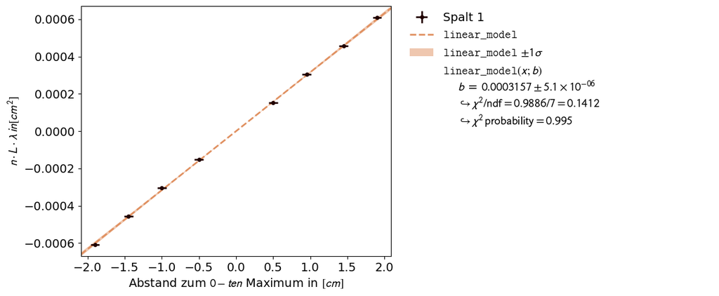

```python
SP_1_x_n = np.array([-1.9, -1.45, -1.0, -0.5, 0.5, 0.95, 1.45, 1.9]) # in cm
n=np.array([-4, -3, -2, -1, 1, 2, 3, 4])
L:float=  240 # in cm
x_err:float= 0.06
L_err:float= 0.1
y_err:float = 632.8E-9 * L_err


SP_1_data = kafe2.XYContainer(x_data=SP_1_x_n, y_data= y_is(n,L))
SP_1_data.label='Spalt 1'
SP_1_data.axis_labels =['Abstand zum $0-ten$ Maximum in $[cm]$','$n\cdot L\cdot\lambda\, in[cm^2]$']
SP_1_data.add_error(axis='x', err_val = x_err)
SP_1_data.add_error(axis='y', err_val = y_err)

SP_1_line_fit=kafe2.Fit(data=SP_1_data,model_function=linear_model)
SP_1_line_fit.do_fit()
SP_1_result = kafe2.Plot([SP_1_line_fit])
SP_1_params = SP_1_line_fit.parameter_values
SP_1_param_errors = SP_1_line_fit.parameter_errors


display(Math(rf'\text{{Die Spaltbreite des ersten Spaltes wird aus dem Fit als }} b_1 = \left({SP_1_params[0]:.02E}\pm{SP_1_param_errors[0]:.02E}\right)\text{{ bestimmt.}} '))
SP_1_result.plot()

plt.show()
```

$\displaystyle \text{Die Spaltbreite des zweiten Spaltes wird aus dem Fit als } b_2 = \left(2.88E-04\pm4.22E-06\right)\text{ bestimmt.}$

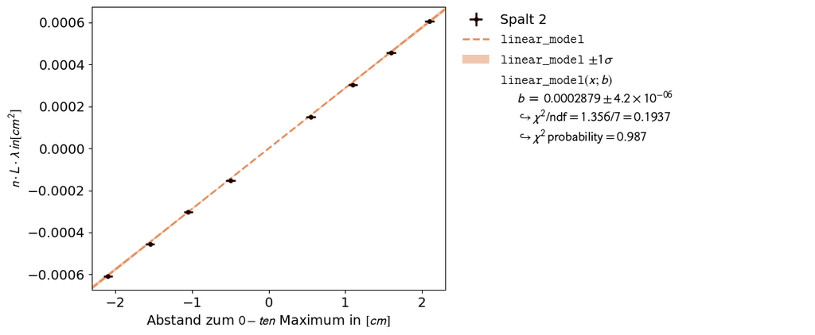

```python
SP_2_x_n = np.array([-2.1, -1.55, -1.05, -0.5, 0.55, 1.1, 1.6, 2.1])


SP_2_data = kafe2.XYContainer(x_data=SP_2_x_n, y_data= y_is(n,L))
SP_2_data.label='Spalt 2'
SP_2_data.axis_labels =['Abstand zum $0-ten$ Maximum in $[cm]$','$n\cdot L\cdot\lambda\, in[cm^2]$']
SP_2_data.add_error(axis='x', err_val = x_err)
SP_2_data.add_error(axis='y', err_val = y_err)

SP_2_line_fit=kafe2.Fit(data=SP_2_data,model_function=linear_model)
SP_2_line_fit.do_fit()
SP_2_result = kafe2.Plot([SP_2_line_fit])
SP_2_params = SP_2_line_fit.parameter_values
SP_2_param_errors = SP_2_line_fit.parameter_errors

display(Math(rf'\text{{Die Spaltbreite des zweiten Spaltes wird aus dem Fit als }} b_2 = \left({SP_2_params[0]:.02E}\pm{SP_2_param_errors[0]:.02E}\right)\text{{ bestimmt.}}'))
SP_2_result.plot()

plt.show()
```

##### Besprechung der Ergebnisse

Es ist auffällig, dass beide Spalte hier $\approx 0.3\,\mathrm{mm}$ als Spaltbreite hatten obwohl eine der Spalten eine breite von $\approx 0.2\,\mathrm{mm}$ haben sollte. Anhand der sehr hohen $\chi^2$ Probability des ersten fits, kann erschlossen werden, dass dieser tatsächlich das $\approx 0.3\,\mathrm{mm}$ Spalt ist. Bei dem zweiten Spalt könnte eine Ungenauigkeit in der Messung dazu geführt haben, dass das Ergebniss so groß ist. Eine weiterer Fehler könnte das Vertauschen des Spaltes sein. Durch eine Unordnung oder falsches zurücklegen der verschiedenen Spalten könnte es sein das zwie Gitter mit der Spaltbreite $\approx 0.3\,\mathrm{mm}$ Verwendet wurden.

#### Aufgabe 2.2

##### Babinetsches Theorem

Das Babinet Theorem besagt, dass die Beugungsmuster fur 2 komplementäre Blenden (Spalt und Steg / Kreisloch und Kreisblende) identisch sind. Dies gilt nur bei der Wellenoptik.

Das Babinet Theorem gilt sowohl in der Fraunhofernäherung als auch für Fresnelbeugung.

##### Aufbau und Erwartung

Es wird hierfür der gleiche Versuchsaufbau verwendet wie in Aufgabe 2.1, lediglich wird aber anstelle der zwei Spalten, einen Spalt mit $b = 0.3 \mathrm{mm}$ und der Steg mit Breite $b= 0.\mathrm{mm}$ verwendet.

Zu erwarten ist, dass die zwei Beugunsmuster größtenteils übereinstimmen. Der Maximum Nullter Ordnung sollte aber unterschiedlich sein, da nach der geometrsichen Optik einen Schatten beim Steg und eien Strich bei der Spalte zu erwarten sind.

##### Ausertung des Versuches

Ein Vergleich der zwei Aufnahmen zeigt, dass die Muster nahezu identisch sind Um den Maximum Nullter Ordnung sind leichte Unterschiede bemerkbar, diese sind Folge zuvor bescprochenen Anteile der Geometrischen Optik. $$ \\ $$

[figure not shown]

$$ \\ $$ **Abbildung 2.2.1:** Beugungsmuster des Spaltes $$ \begin {array}{c} \\ \\ \\ \\ \end{array} $$

[figure not shown]

$$ \\ $$ **Abbildung 2.2.2:** Beugungsmuster des Stegs

#### Aufgabe 2.3

##### Versuchsaufbau und -durchführung

Es wird im Strahlengang des Lasers im ersten Bild eine Kreisblende und im zweiten einen Kreisscheibe gehalten. Die Beugungsmuster werden danach verglichen. Anschließend wird noch das Interferenzmuster von einer Kante untersucht.

##### Auswertung

Untermittelbahr hinter der Scheibe auf dem Schirm kommt es stehts zu konstruktive Interferenz. Dadurch entsteht immer ein heller (in diesem Fall auch kreisförmiger) Fleck hinter dem Hinderniss zu sehen. Dieser Fleck ist auch als Poisson-Fleck bekannt.

Wie in Aufgabe 2.2 bei dem Steg und Splat, sind auch hier die Interferenzmuster der Kreisblende und -schiebe sehr ähnlich. In beiden Bildern ist das Beugungsmuster zu sehen aber bei der Scheibe sind diese klarer. Zudem ist bei der Scheibe auch eine Abdunklung im bereich des Poisson-Flecks zu erkennen, dieser ist Vermutlich eine Folge des in der geometrischen Optik erwartetem Schattens.

Eine Aufnahme des Musters hinter einer Kante wurde im laufe des Versuches nicht aufgenommen. Die Folgende Beobachtung bassiert auf **[eine Viedoaufnahme des Versuches](https://www.youtube.com/watch?v=0ZfrNDtH05w)**. Fur die Interferenz an einer Beugungskante (offene Seite links) ist ein Beugungsmuster, dass auf der linken, offenen Seite dem Muster eines Einzelspalts entsprach. Minima und Maxima verschiedener Ordnung sind gut erkennbar. Auf der rechten, geschlossenen Seite ergab sich ein durchgehender Lichtstrahl, dessen Intensität allerdings zunehmend und rasch abnahm. Die im verlinkten Video gezeigte Aufnahme zeigt diese Beobachtungen deutlich.

$$ \\ $$

[figure not shown]

$$ \\ $$ **Abbildung 2.3.1:** Beugungsmuster der Kreisblende

[figure not shown]

$$ \\ $$ **Abbildung 2.3.1:** Beugungsmuster der Kreisscheibe

#### Aufgabe 2.4

##### Versuchsaufbau und -durchführung

Zuerst wird die Dicke eines Haares mithilfe einer Mikrometerschraube vermessen bevor das Haar im gespanntem Zustand im Strahlengang des Lasers angebracht wird. So verhält es sich wie einen Steg und somit gilt die in Aufgabe 2.2 verwendete Gleichung $$ b = \frac{n\lambda L}{x_n} $$

Aus der Literatur erhält man, dass ein normales Kopfhaar eine Dicke von $\approx 0.05 \mathrm{mm}\,\text{bis } 0.07 \mathrm{mm}$ $$ \\ $$

[figure not shown]

$$ \\ $$

##### Auswertung

Es wird analog zur bestimmung der Spaltbreite gearbeitet. Mit der Mikrometerschraube wird die dicke $d_{schraube} = 70\,\mathrm{\mu m}$. Die durch dem Fit ermittelte dicke des Haars ist $\approx 70\, \mathrm{\mu m}$ und stimmt somit mit dem Wert welcher die Scraube ergab.

$\displaystyle \text{Die Haarbreite wird aus dem Fit als } b_{Haar} = \left(7.02E-05\pm5.07E-07\right)\text{ bestimmt.}$

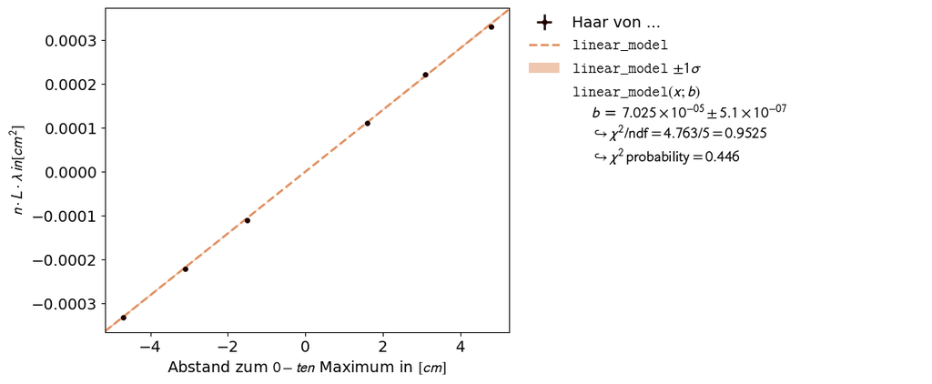

```python
def y_is (n,L, lam = 632.8E-9):

    y  = (n*L*lam)
    return y

def linear_model(x,b):
    return b*x



H_x_n=np.array([-4.7, -3.1, -1.5, 1.6, 3.1, 4.8]) # in cm
H_n=np.array([-3, -2, -1, 1, 2, 3])
H_L:float=  174.5 # in cm


H_xy_data = kafe2.XYContainer(x_data=H_x_n, y_data= y_is(H_n,H_L))
H_xy_data.label='Haar von ...'
H_xy_data.axis_labels =['Abstand zum $0-ten$ Maximum in $[cm]$','$n\cdot L\cdot\lambda\, in[cm^2]$']
H_xy_data.add_error(axis='x', err_val = x_err)
H_xy_data.add_error(axis='y', err_val = y_err)

H_line_fit=kafe2.Fit(data=H_xy_data,model_function=linear_model)
H_line_fit.do_fit()
H_result = kafe2.Plot([H_line_fit])
H_params = H_line_fit.parameter_values
H_param_errors = H_line_fit.parameter_errors


display(Math(rf'\text{{Die Haarbreite wird aus dem Fit als }} b_{{Haar}} = \left({H_params[0]:.02E}\pm{H_param_errors[0]:.02E}\right)\text{{ bestimmt.}}'))
H_result.plot()
plt.show()
```

### **Aufgabe 3: Beugung an Mehrfachspalten und Gittern**

**3.1:** Bestimmen Sie die Spaltbreite $b$ und den -abstand ($\ell$) eines der Doppelspalte aus dessen Beugungsbild.

**3.2:** Machen Sie eine Voraussage und beobachten Sie dann:

1. wie sich das Beugungsbild bei Verwendung eines zweiten Doppelspalts ändert; und
2. wie sich das Beugungsbild des Dreifachspalts von dem des Doppelspalts (jeweils mit der Spaltbreite $b=0,25\,\mathrm{mm}$ und dem Spaltabstand $\ell=0,5\,\mathrm{mm}$) unterscheidet.

**3.3:** Bestimmen Sie die Gitterkonstante $g$ eines der Strichgitter. Beobachten Sie das Beugungsbild. Diskutieren Sie welche Rolle dabei die Ausleuchtung spielt.

**3.4:** Beobachten Sie Beugungsbilder von Kreuz- und Wabengittern.

**Lösung:**

#### Aufgabe 3.1

##### Vorüberlegungen

Die Spaltbreite und der Spaltabstand eines Doppelgitters aus dem Interferenzmuster abzulesen sind folgende Größen von relevanz:

- n: Nummer des Minimums/Maximums
- $L, \sigma_{L}$: Abstand zwischen Spalt und Schirm und seine Unsicherheit $\left(174.5\, \mathrm{cm} \right)$
- $\lambda$: Die Wellenlänge des Verwendetem Lichtes $\left(632.8\,\mathrm{nm}\right)$
- $x_{n},\sigma_{x}$: Abstand des n-ten Minimums und seine Unsicherheit
- $y_n, \sigma_{y}$: Abstand des n-ten Maximums und seine Unsicherheit

Die Formel zur Bestimmung des Spaltabstandes lautet: $$ g = \frac{n\cdot\lambda\cdot L}{y_n} $$

Und die Formel für die Spaltbreite ist: $$ b = \frac{n\cdot\lambda\cdot L}{x_n} $$

##### Aufbau und Druchführung

$$ \\ $$

[figure not shown]

$$ \\ $$ **Abbildung 3.1:** Interferenzmuster des Dopelspaltes

##### Messdaten

Die angegebene Werte für den verwendeten Doppelspalt lauten: $\mathrm{b}=0.2\,\mathrm{mm}$, gemessen wurde der Abstand zwischen den Minima und dem Maximum nullter Ordnung.

$\displaystyle \text{Die Spaltbreite wird aus dem Fit als } b_{DP} = \left(1.96E-04\pm2.69E-06\right)\text{ bestimmt.}$

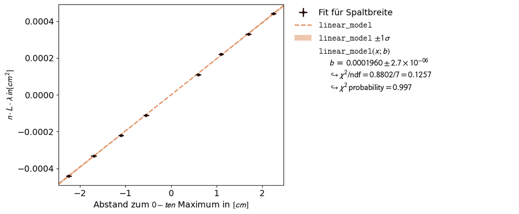

```python
DP_x_n = np.array([-2.25, -1.7, -1.1, -0.55, 0.6, 1.1, 1.7, 2.25]) # abstand der Minima in cm

DP_n=np.array([-4, -3, -2, -1, 1, 2, 3, 4])
L:float=  174.5 # in cm


DP_data = kafe2.XYContainer(x_data=DP_x_n, y_data= y_is(DP_n,L))
DP_data.label='Fit für Spaltbreite'
DP_data.axis_labels =['Abstand zum $0-ten$ Maximum in $[cm]$','$n\cdot L\cdot\lambda\, in[cm^2]$']
DP_data.add_error(axis='x', err_val = x_err)
DP_data.add_error(axis='y', err_val = y_err)

DP_line_fit=kafe2.Fit(data=DP_data,model_function=linear_model)
DP_line_fit.do_fit()
DP_result = kafe2.Plot([DP_line_fit])
DP_params = DP_line_fit.parameter_values
DP_param_errors = DP_line_fit.parameter_errors

display(Math(rf'\text{{Die Spaltbreite wird aus dem Fit als }} b_{{DP}} = \left({DP_params[0]:.02E}\pm{DP_param_errors[0]:.02E}\right)\text{{ bestimmt.}}'))
DP_result.plot()
plt.show()
```

Für die Spaltanstand werden die zuvor erwähnte Messdaten einer anderen Gruppe verwendet.

$\displaystyle \text{Die Spaltanstand wird aus dem Fit als } g_{DP} = \left(3.33E-04\pm4.58E-06\right)\text{ bestimmt.}$

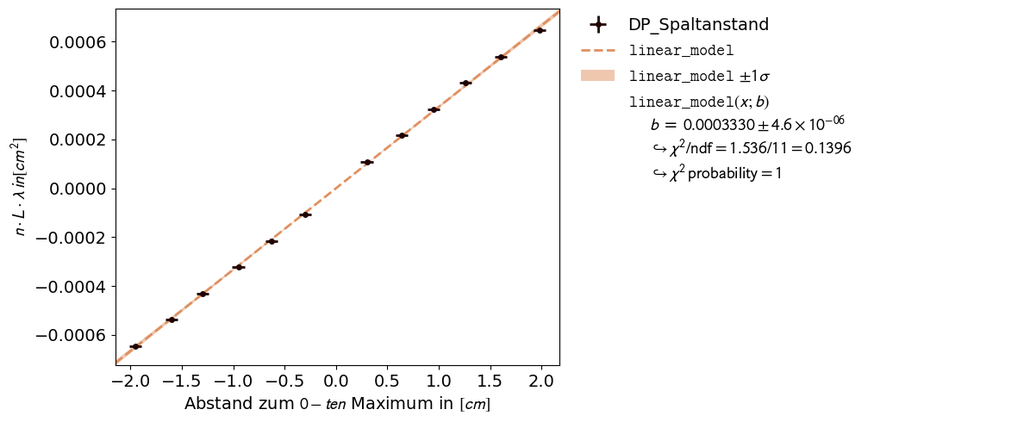

```python
DP_y_n = np.array([-1.95, -1.6, -1.3, -0.95, -.63, -0.3, 0.3, 0.64, 0.95, 1.26, 1.6, 1.98])#in cm
DP_n_maxima = np.array([-6,-5,-4,-3,-2,-1,1,2,3,4,5,6])
L_maxima = 170 # in cm


DP_data = kafe2.XYContainer(x_data=DP_y_n, y_data= y_is(DP_n_maxima,L_maxima))
DP_data.label='DP_Spaltanstand'
DP_data.axis_labels =['Abstand zum $0-ten$ Maximum in $[cm]$','$n\cdot L\cdot\lambda\, in[cm^2]$']
DP_data.add_error(axis='x', err_val = x_err)
DP_data.add_error(axis='y', err_val = y_err)

DP_line_fit=kafe2.Fit(data=DP_data,model_function=linear_model)
DP_line_fit.do_fit()
DP_result = kafe2.Plot([DP_line_fit])
DP_params = DP_line_fit.parameter_values
DP_param_errors = DP_line_fit.parameter_errors

display(Math(rf'\text{{Die Spaltanstand wird aus dem Fit als }} g_{{DP}} = \left({DP_params[0]:.02E}\pm{DP_param_errors[0]:.02E}\right)\text{{ bestimmt.}}'))
DP_result.plot()
plt.show()
```

#### Afugabe 3.2

##### Voraussage

**Spaltabstand**

- Eine Erhöhung des Spaltabstandes wird folgende Auswirkungen haben:
  - Interferenzmaxima liegen näher beieinander
  - Interferenzmuster wird feiner, d.h., dass die Anzahl der maxima pro $\degree$ größer wird
  - Gleiche Internsitätsverteilung, lediglich eine änderung der Position der Maxima
- Eine Verringerung des Spaltabstandes wird folgende Auswirkungen haben:
  - Die Interferenzmaxima liegen weiter auseinander.
  - Das Interferenzmuster wird grober, d.h., die Anzahl der Maxima pro $\degree$ wird kleiner.
  - Die Intensitätsverteilung bleibt gleich, nur die Positionen der Maxima ändern sich.

**Spaltbreite**

- Breitere Spalte:
  - Die Hauptmaxima der Einzelspaltbeugung werden schmaler und intensiver.
  - Die Nebenmaxima der Einzelspaltbeugung sind weniger stark ausgeprägt.
  - Das Interferenzmuster bleibt innerhalb der Hüllkurve der Einzelspaltbeugung sichtbar, aber die Hüllkurve selbst wird schmaler.
- Schmalere Spalte
  - Die Hauptmaxima der Einzelspaltbeugung werden breiter und weniger intensiv.
  - Die Nebenmaxima der Einzelspaltbeugung sind stärker ausgeprägt.
  - Das Interferenzmuster bleibt innerhalb der Hüllkurve der Einzelspaltbeugung sichtbar, aber die Hüllkurve selbst wird breiter.

**Vergleich zum Dreifachspalt**

- Es gibt mehr Maxima als bei dem Doppelspalt
- Zwischen den Hauptmaxima gibt es schwache Nebenmaxima
- Intensität der Maxima ist höher und sie sind schärfer
- Hauptmaxima an den selben stellen

##### Versuchesergebnisse

Die verwendete Dopplespalte besitzen beide die selbe Spaltbreite, das einzige was Variert wurde ist der Spaltabstand.

Die Doppelspalte hatten jeweils $g_{groß}=1\mathrm{mm}\quad g_{klein}=0.25\mathrm{mm}$ als Spaltabstand.

Die Vorüberlegungen bestätigen sich. In beiden Muster gibt es einen Maximum, welcher erloschen wird, und dieser befindet sich beide male grob an der selben Stelle. Dagegen aber ist der Muster in Abbildung 3.2.1 breiter als der in Abbildung 3.2.2 dies tut auch unsere Vorüberlegung bestätigen.

Die Überlegungen bezüglich des Unterschiedes zum Dreifachspalt bestätigen sich auch. Die Nebenmaxima wurden beobachtet aber es konnte keine Aussage über die Schärge der Maxima getroffen werden.. $$ \\ $$

[figure not shown]

$$ \\ $$ **Abbildung 3.2.1:** Muster eines Doppelspalt mit kleinem l $$ \\ $$

[figure not shown]

$$ \\ $$ **Abbildung 3.2.2:** Muster eines Doppelspalt mit großem l

#### Aufgabe 3.3

##### Aufbau und Vorbereitung

Die Gitterkonstante eines Strichgitters soll bestimmt werden, hierzu wird der Abstand $x_n$ des $n$-ten Maximums von der Mitte des Beugungsbildes gemessen werden. Die Gitterkonstante des Strichgitters wird, zuvor bereits erwähnt mithilfe der Formel $$ g = \frac{n\lambda L}{x_n} $$ bestimmt.

Die Ausleuchtung sollte den Interferenzmuster nicht qualitativ beinflüßen, lediglich eine höhere Intensität der Maxima ist zu erwarten.

##### Durchführung

Bei einem Abstand von $L=174.5\mathrm{cm}$ wird der selbe Laser verwendet. Der einzige Untershied ist, dass nun ein Gitter verwendet wird. Die Maxima werden anschlißend auf Millimeterpapier markiert um die Messwerte zu ermitteln.

[figure not shown]

$$ \\ $$ **Abbildung 3.3:** Muster eines Gitters

$\displaystyle \text{Die Gitterkonstante wird aus dem Fit als } g = \left(1.25E-04\pm1.09E-06\right)\text{ bestimmt.}$

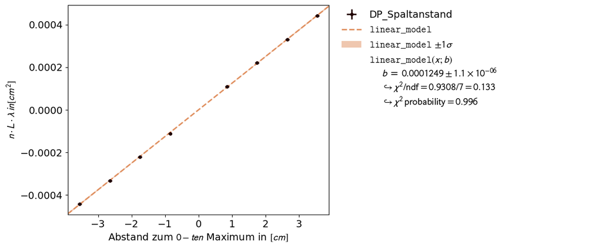

```python
G_x_n = np.array([-3.55, -2.65, -1.75, -0.85, 0.85, 1.75, 2.65, 3.55])#in cm
G_n_maxima = np.array([-4,-3,-2,-1,1,2,3,4])
L_maxima = 174.5 # in cm


G_data = kafe2.XYContainer(x_data=G_x_n, y_data= y_is(G_n_maxima,L_maxima))
G_data.label='DP_Spaltanstand'
G_data.axis_labels =['Abstand zum $0-ten$ Maximum in $[cm]$','$n\cdot L\cdot\lambda\, in[cm^2]$']
G_data.add_error(axis='x', err_val = x_err)
G_data.add_error(axis='y', err_val = y_err)

G_line_fit=kafe2.Fit(data=G_data,model_function=linear_model)
G_line_fit.do_fit()
G_result = kafe2.Plot([G_line_fit])
G_params = G_line_fit.parameter_values
G_param_errors = G_line_fit.parameter_errors

display(Math(rf'\text{{Die Gitterkonstante wird aus dem Fit als }} g = \left({G_params[0]:.02E}\pm{G_param_errors[0]:.02E}\right)\text{{ bestimmt.}}'))
G_result.plot()
plt.show()
```

##### Auswertung

Die im Fit ermittelte Gitterkonstante lautet: $g=0.125\pm 1.09\cdot10^{-6}\mathrm{mm}$, Dieses Ergebniss stimmt mit dem angegebenem Wert von 80 Striche pro cm überein.

#### Aufgabe 3.4

##### Vorüberlegung

Das Beugungsbild eines Kreuz- und eines Wabengitters soll beobachtet werden. Zu erwarten ist, dass das Beugungsbild eines Kreuzgitters der Superposition von zwei senkrecht aufeinander stehenden Liniengitter entspricht. Das Wabengitter wird dann ein vom Kreuzgitter abgewandeltes Beugungsbild besitzen.

##### Durchführung

Es wurde das L und das verwendete Laser nicht verändert. Nacheinander wir ein Kreuzgitter anstelle des Strichgitters aus Aufgabe 3.3 vwerwendet und danach das Wabengitter im Lichtgang montiert.

##### Auswertung

Wie in den unteren Abbildungen zu sehen, ist das Beugungsbild des Kreuzgitters dem einer Überlagerung der Beugungsbilder zweier senkrechter Gitter gleich. Dagegen ist ein Strernmuster bei dem Wabengitter zu beobachten.

[figure not shown]

$$ \\ $$

**Abbildung 3.4.1:** Inferferenzmuster des Kreuzgitters $$ \\ $$

[figure not shown]

$$ \\ $$ **Abbildung 3.4.2:** Inferferenzmuster des Kreuzgitters

### **Aufgabe 4: Abbildung nichtselbstleuchtender Gegenstände (Abbésche Theorie#Abbe-Limit))**

Zeigen Sie, dass für die Abbildung durchstrahlter Objekte das Beugungsmuster des Lichts eine wichtige Rolle spielt. Gehen Sie dabei wie folgt vor:

Beleuchten Sie, je nach Wahl, ein Waben- oder Strichgitter (mit $100\,\mathrm{Strichen/cm}$) mit parallelem Licht und bilden Sie das Beugungsbild mit Hilfe einer Linse mit $150\,\mathrm{mm}$ Brennweite auf eine Mattscheibe ab. Sie können das Licht zuvor mit Hilfe eines fernen Planspiegels umlenken, so dass Sie die Mattscheibe in Lasernähe neben der optischen Bank positionieren und das Beugungsbild beim Justieren beobachten können.

Eine [Beugungsordnungsblende](https://de.wikipedia.org/wiki/Beugungsscheibchen) in der bildseitigen Brennebene der Linse lässt das Beugungslicht entweder nur 0. oder 0. und 1. Ordnung durch. Da die Beugungsordnungsblende schwierig zu justieren ist, können Sie die 0. Ordnung auch mit einer Kreisblende (mit Durchmesser $d=1\,\mathrm{mm}$) ausblenden. Beobachten Sie das jeweils auf der Mattscheibe entstehende Bild. Versuchen Sie auch die Beobachtung der folgenden zwei weiteren Fälle: **Nur die 1. Ordnung** oder **nur die 2. Ordnung** passieren die Beugungsordnungsblende. Gitter, Linse und die dazu passende Beugungsordnungsblende werden in einem Justieraufbau montiert, die Beugungsordnungsblende kommt dabei in die nach allen Richtungen transversal zum Strahl verschiebbare Fassung. Zeichnen Sie zu diesem Versuch bei der Vorbereitung den Strahlengang. Wie könnte man den beobachteten Effekt benutzen, um etwa bei einem digitalisiert empfangenen Zeitungsbild das störende Raster verschwinden zu lassen? (Stichwort 'Image Enhancement'; Literatur: Hecht/Zajac)

**Lösung:**

#### Vorbereitung

##### Vorüberlegungen und Skizzze

[figure not shown]

$$ \\ $$ **Abblidung 4.1:** Bild eines Strahlengangs $^{[2]}$

Betrachtet man nur die 0-te Beugungsordnung, so erhält man ein Bild ohne Konturen somit lediglich einen hellen Fleck. Werden weitere Beugungsordnungen durchgelassen, soll das Bild immer kontrastreicher je mehr Ordnungen hinzukommen. Dem entsprechend ist zu erwarten, dass man nur noch die Konturen des durchschienenen Objekts zu sehen sind. Davon macht man sich beispielsweise in der Biologie gebrauch.

##### Image Enhancement

Um 'Image Enhancement' besser zu verstehen, betrachte man die Bildentstehung im Fourierraum. Um genau zu sein, handelt es sich hierbei um einen 2-dimensionalen Fouriertraum. Durch das Zerlegen eines Bildes in die einzelnen Sinus- und Cosinunkompunenten kann Information über verschiedene Muster im Bild gewonnen werden. Mit der gewonnenen Informationen, kann der Rausch bzw. störende Muster im Bild klar definiert werden. Unterdrückt man diese (in der Regel höhere) Frequenzen, kann die Qualität des Bildes deutlisch verbessert werden. $^{[3]}$

#### Aufnahmen aus dem Versuch

[figure not shown]

$$ \\ $$ **Abbildung 4.2:** Durchlassung des 0. Maximums

$$ \\ $$

[figure not shown]

$$ \\ $$ **Abbildung 4.3:** Durchlassung des 1. Maximums

$$ \\ $$

[figure not shown]

$$ \\ $$ **Abbildung 4.4:** 0. und 1. Maximum werden durchgelassen

#### Besprechung der Ergebnisse

Es wurde für die Aufnahmen ein Kreuzgitter verwendet.

Genau das was in der Vorbereitung diskutiert wurde ist hier wiederzu finden.

In Abbildung 4.2 ist vor allem den stark leuchtendem Fleck von Bedeutung denn dieser ist der 0. Maximum.

In Abbildung 4.3 fehlt der innere Fleck und es bleiben nur die Maxia erster Ordnung um ihn herum.

Und in Abbildung 4.4 sinde beide zusammen abgebildet.

$^{[2]}$: [Heintze, J., Bock, P. (2017). Beugung. In: Bock, P. (eds) Lehrbuch zur Experimentalphysik Band 4: Wellen und Optik. Springer Spektrum, Berlin, Heidelberg.](https://doi.org/10.1007/978-3-662-54492-1_8)

$^{[3]}$: Patrisha Estrada (2023), The Art of Image Enhancement

### **Aufgabe 5: Holographie**

Reproduzieren Sie ein Hologramm. Vergleichen Sie das reelle mit dem virtuellen Bild.

Weiten Sie den Laserstrahl hierzu jeweils geeignet auf. Überzeugen Sie sich davon, dass Sie wirklich **dreidimensional** beobachten können, d.h. dass sich je nach Beobachtungsposition die Perspektive ändert und zunächst verborgene Details des Hologramms ggf. sichtbar werden. Das reelle Bild kann auf einem Schirm (weißes Papier) aufgefangen werden. Bewegen Sie den Schirm durch das Strahlungsfeld. Zeigen Sie, dass die Information über ein Gegenstandsdetail nicht nur an einer bestimmten Stelle des Hologramms gespeichert ist. Decken Sie hierzu verschiedene Bereiche des zunächst weit ausgeleuchteten Hologramms ab. Dokumentieren und diskutieren Sie Ihre Beobachtungen.

**Lösung:**

##### Vorüberlegungen

In einem Hologramm werden die Phaseninformationen des abgebildetem Objektes gespeichert. Um einen Hologramm herzustellen, wird ein Objekt mit monochromatischen Licht beleuchtet und sowohl das Interferenzmuster des Lichtes als auch die Beugung an dem Objekt aufgezeichnet. Beleuchtet man das Hologramm erneut mit Licht der selben Wellenlänge, wird das ursprüngliche Bild in einem bestimmten Bereich räumlich abgebildet.

Wichtig ist hier festzuhalten, dass die Information nicht an einer Stelle festgehalten wird. Alle vom Hologramm ausgehenden Elementarwellen tragen einen kleinen Teil mit ihrer Amplitude und ihrer Phase zur Entstehung der Abbildung bei. Deshalb können Teile des Hologramms abgedeckt werden ohne das Bild zu zerstoren. Es werden lediglich einzelne Details dabei verloren.

##### Durchfürhung

In dieser Aufgabe wurde ein aufgeweiteter Laserstrahl benutzt, um ein Hologramm zu reproduzieren. Durch Veranderung des Blickwinkels bei der direkten Betrachtung des Hologramms könnte nachgewiesen werden, dass sich die Perspektive jeweils ändert und je nach Kopfhaltung auch unterschiedliche Details wahrgenommen werden können. Die Abbildungen 5.1 und 5.2 versuchen diesen Eindruck wiederzugeben.

Im nächstem Schritt wurde dann das reelle Bild auf einem Schirm abgebildet. Je nach Stellung des Schirms wurden unterschiedliche Details auf auf dem Schirm erkennbar. Grund dafür waren wieder die unterschiedlichen Perspektiven. Bemerkenswert ist, dass das Bild selbst zweidimensional war.

Um zu untersuchen wie die Information gespiechert wurde, wird das Hologramm teilweise verdeckt. Dies führte nicht zu einem Verlust an Bildinformationen, sondern einem - wie in den Vorüberlegungen bereits erwähnt - Verlust einzelner Details und eine algemeine unschärfe des Hologramms.

[figure not shown]

$$ \\ $$ **Abbildung 5.1:** 1. Perspektive aus das Hologramm

$$ \\ $$

[figure not shown]

$$ \\ $$ **Abbildung 5.2:** 2. Perspektive aus das Hologramm